# Data Analysis 6 by Eric Braun

# Univariate Analysis

The obvious question to ask with this data is how the various properties of the wine correspong to the quality. In a broad way this provides an answer to the question- what makes a good bottle of red wine?

There are other questions to look at, though. Three variables involve acid, do those values correlate in some way? Similarly, many variables result as natural byproducts of fermentation. Do they relate to each other in a meaningful way?

It was not necessary to create any new variables in this dat set.

Most of the data is distributed in a relatively smooth way. Many are bell curves others have tails. One odd distribution though is found in amount of citric acid. This is generally a pattern of decrease, there are more bottles with less citric acid. However, there are many peaks that appear within this bigger trend. There is still a clear pattern, but there is more noise than other variables.

# Bivariate Plots Section

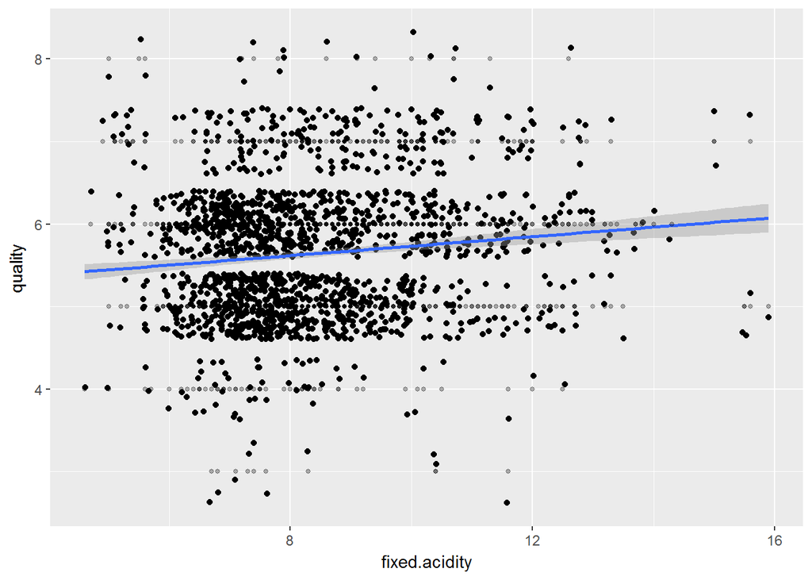

```
## [1] 0.1240516
```

Here we see the relationship between fixed.acidity and quality. There seems to be a slight positive correlation of .124 between the two.

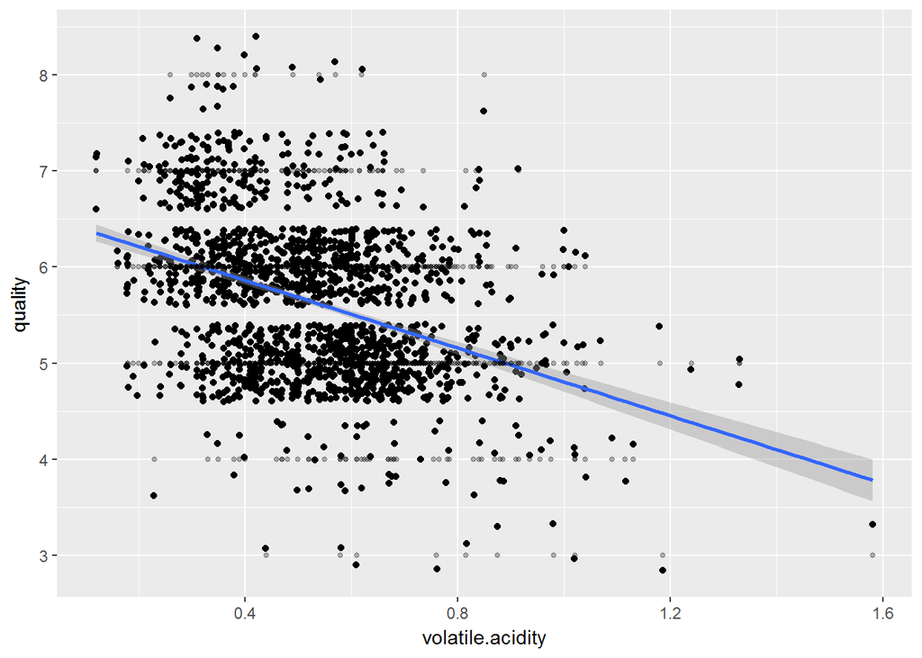

```
## [1] -0.3905578
```

There is a stronger negative relationship of -.39 in this graph comparing volatile acidity and quality.

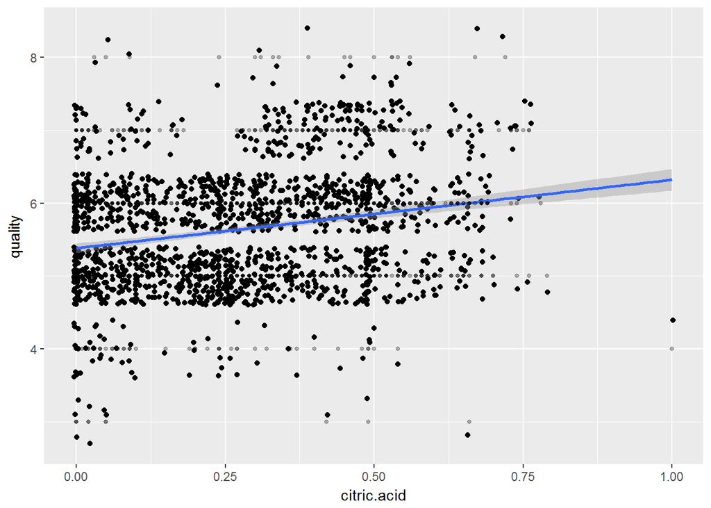

```
## [1] 0.2263725
```

There appears to be a slight positive correlation of .226 between citric acid and quality.

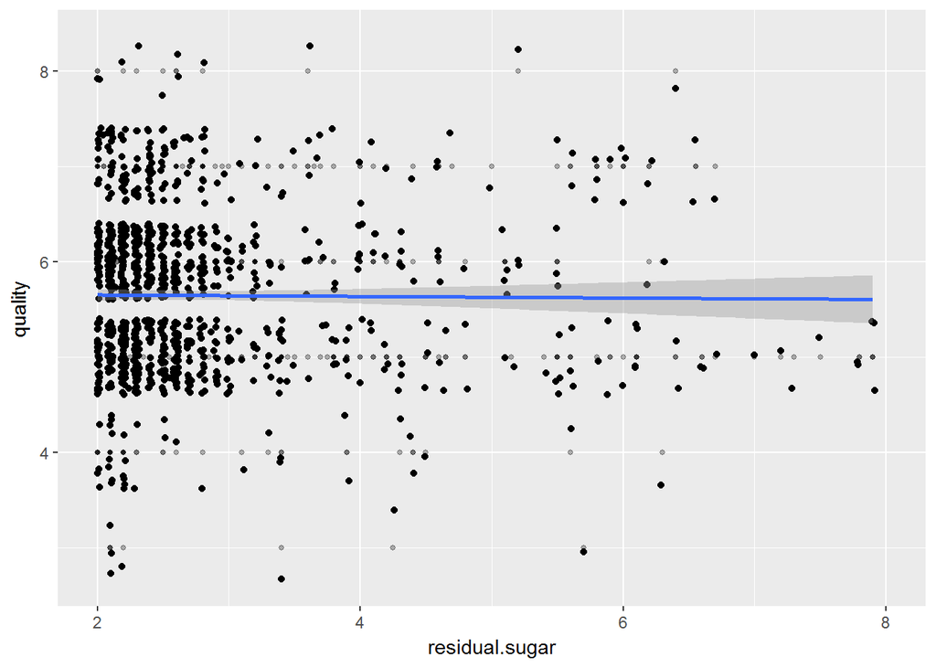

```
## [1] 0.01373164
```

There is a slight positive correlation of .0137, essentially nil between residual sugar and quality.

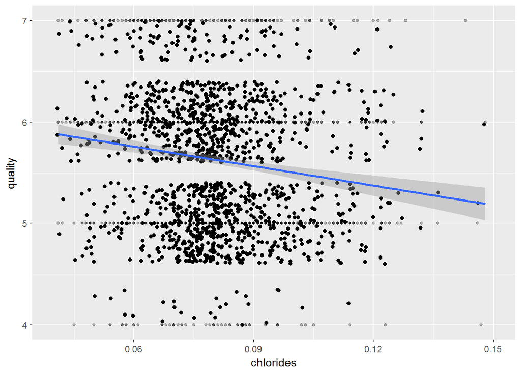

```
## [1] -0.1289066
```

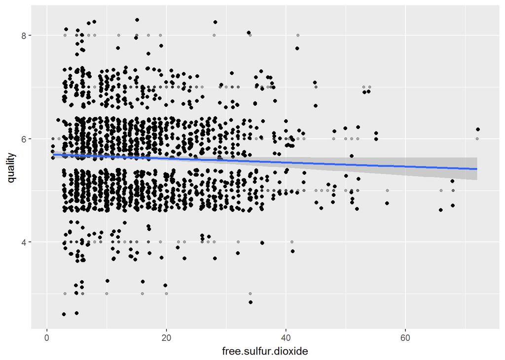

```
## [1] -0.05065606
```

The correlation in this example is -.05, practically non-existent .

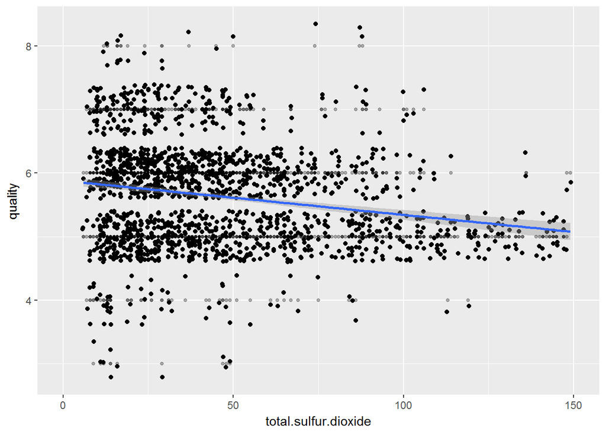

```
## [1] -0.1851003
```

Here there is a clearer relationship than in the last example. The correlation is -.18.

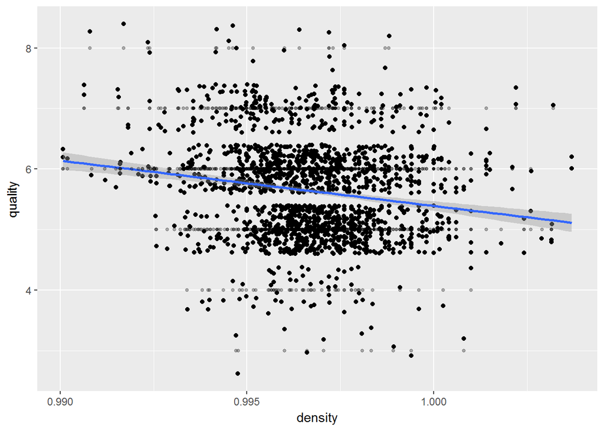

```
## [1] -0.1749192
```

Here there is a slight negative correlation of -.175 between density and quality.

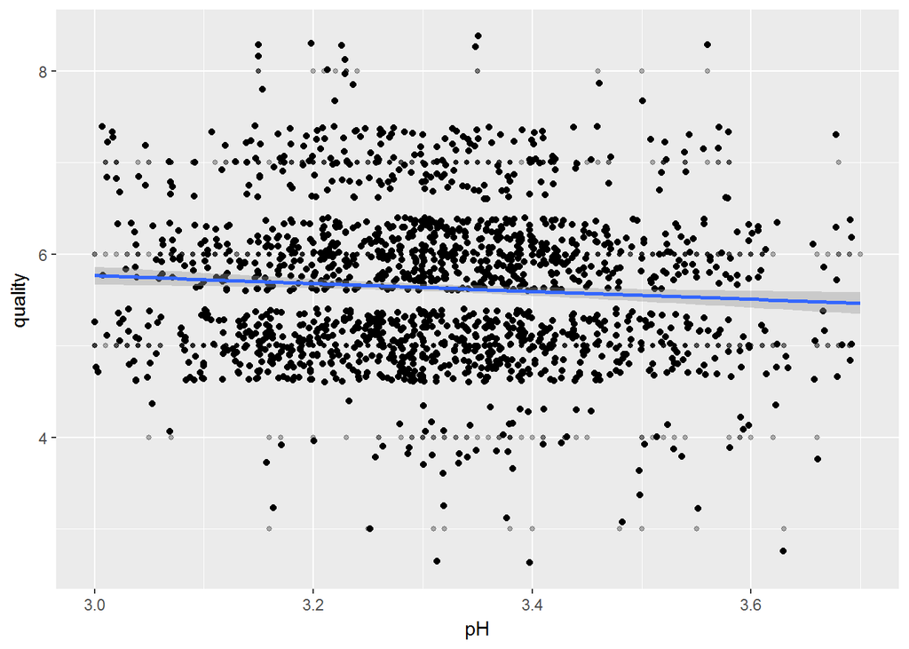

```
## [1] -0.05773139
```

There is not much of a correlation between pH and quality, -.0577.

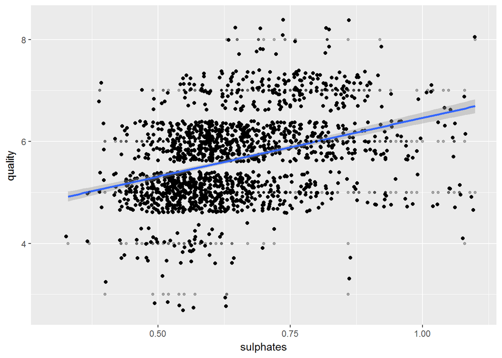

```
## [1] 0.2513971
```

The appears to be a relatively strong positive correlation of .251 between sulphates and quality.

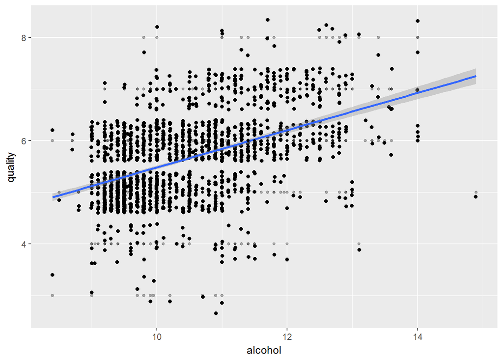

```
## [1] 0.4761663
```

There is a fairly strong correlation between alcohol content and quality, .476.

# Other Bivariate Plots

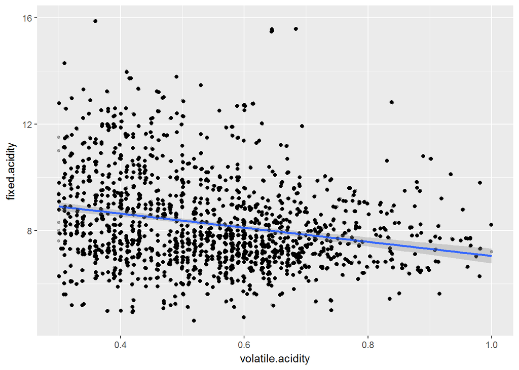

```
## [1] -0.2561309
```

There is a moderate negative correlation of -.256 between fixed and volatile acidity.

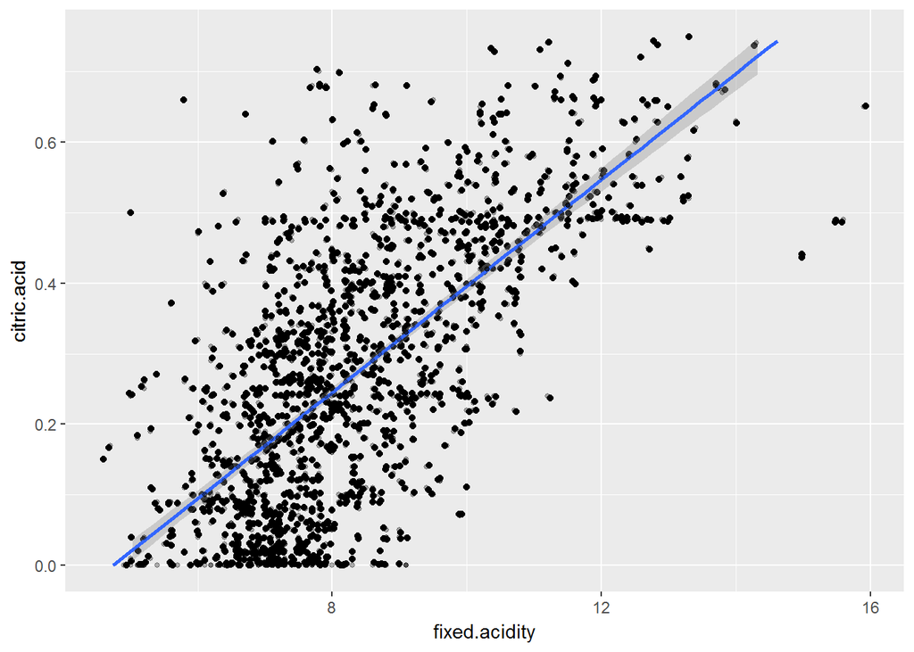

```
## [1] 0.6717034
```

There is a strong positive relationship of .671 between fixed acidity and citric acid.

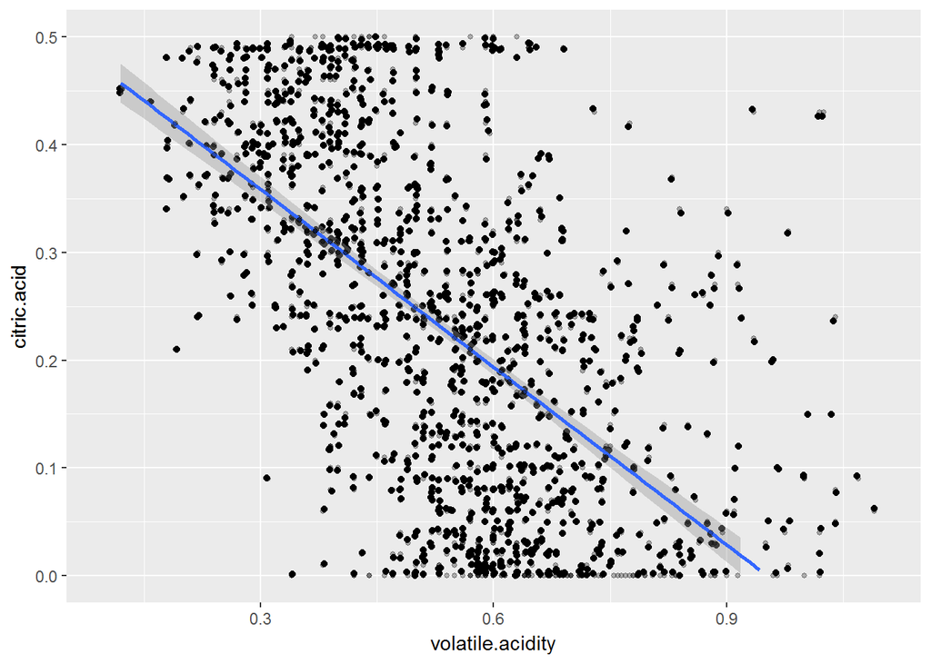

```
## [1] -0.5524957
```

There is a strong negative correlation of .552 between volatile acidity and citric acid.

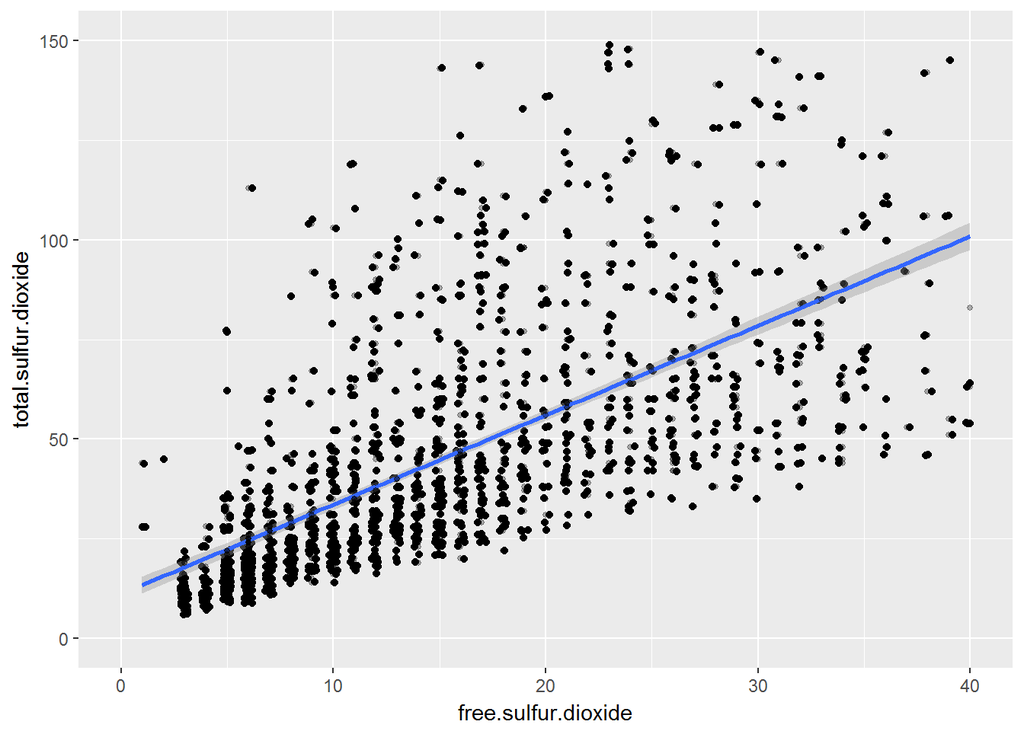